# H2O Regression Modeling

Evan Carey, created for BH Analytics

# Overview

- Machine Learning Regression Review
- Implementing GLMs
- Regularized GLMs
- Hyperparameter grid searches
- Random Forests
- Automatic Machine Learning

# Regression Models in Machine Learning

- We will now focus on supervised machine learning, where the outcome is continuous.
- This is typically referred to as regression, and we will be estimating the mean of the outcome as a function of various predictors.
- We assume you have already learned about the general steps in machine learning, and we will focus on the implementation in H2O.
- Here is a quick review -
- We start with data import and cleaning
  - You should implement any feature engineering at this stage
  - Examine the data for missingness
  - Examine the data for colliniarity of predictors
  - Identify any low variance predictors (near constant or constant predictors)
- Next we establish training, validation, and testing data.
- You may decide to use k-folds cross validation in place of a single validation data split
- We will decide on the function to use for optimizing and evaluating the models (AIC, mean squared error, etc)
- We will fit various models to the training data, using the validation data (or internal cross-validation) to optimize hyper-parameters.
- We will identify the best model (or ensemble of models), then evaluate the results on the test set.
- Compare the model performance on the training data, the validation data, and the testing data for consistency.
- Large decreases in performance on the testing data (compared to training/validation) indicates we have overfit.
- And always remember…it is highly unlikely that your model will fit this good on future data, due to the inherent challenge of truly approximating ‘out of sample data’ from your dataset.

# Data Example: Median Home Prices in Texas

- We will use some home sale price data from Texas, that is available in the ggplot2 pack in R.
- First I initialize the session, then we load up the data from R.

```r
# Load
library(data.table)
library(h2o)
library(Hmisc)

# Initiate h2o session
h2o.init(ip='localhost',
         port = 54321,
         nthreads = -1,  # use all available threads
         max_mem_size = '2G') # can also specify mem size
```

```
##  Connection successful!
##
## R is connected to the H2O cluster:
##     H2O cluster uptime:         35 minutes 45 seconds
##     H2O cluster timezone:       America/Chicago
##     H2O data parsing timezone:  UTC
##     H2O cluster version:        3.30.1.1
##     H2O cluster version age:    13 days
##     H2O cluster name:           H2O_started_from_R_evancarey_pys370
##     H2O cluster total nodes:    1
##     H2O cluster total memory:   1.76 GB
##     H2O cluster total cores:    8
##     H2O cluster allowed cores:  8
##     H2O cluster healthy:        TRUE
##     H2O Connection ip:          localhost
##     H2O Connection port:        54321
##     H2O Connection proxy:       NA
##     H2O Internal Security:      FALSE
##     H2O API Extensions:         Amazon S3, Algos, AutoML, Core V3, TargetEncoder, Core V4
##     R Version:                  R version 3.6.3 (2020-02-29)
```

```r
# clean slate
h2o.removeAll()
h2o.ls()
```

```
## [1] key
## <0 rows> (or 0-length row.names)
```

```r
## Use texas housing data for regression
library(ggplot2)
data("txhousing")
## notice the missing!
describe(txhousing)
```

```
## txhousing
##
##  9  Variables      8602  Observations
## -----------------------------------------------------------------------------------------------------------------------------------------------------
## city
##        n  missing distinct
##     8602        0       46
##
## lowest : Abilene       Amarillo      Arlington     Austin        Bay Area     , highest: Texarkana     Tyler         Victoria      Waco          Wichita Falls
## -----------------------------------------------------------------------------------------------------------------------------------------------------
## year
##        n  missing distinct     Info     Mean      Gmd      .05      .10      .25      .50      .75      .90      .95
##     8602        0       16    0.996     2007    5.189     2000     2001     2003     2007     2011     2014     2014
##
## lowest : 2000 2001 2002 2003 2004, highest: 2011 2012 2013 2014 2015
##
## Value       2000  2001  2002  2003  2004  2005  2006  2007  2008  2009  2010  2011  2012  2013  2014  2015
## Frequency    552   552   552   552   552   552   552   552   552   552   552   552   552   552   552   322
## Proportion 0.064 0.064 0.064 0.064 0.064 0.064 0.064 0.064 0.064 0.064 0.064 0.064 0.064 0.064 0.064 0.037
## -----------------------------------------------------------------------------------------------------------------------------------------------------
## month
##        n  missing distinct     Info     Mean      Gmd      .05      .10      .25      .50      .75      .90      .95
##     8602        0       12    0.993    6.406     3.96        1        2        3        6        9       11       12
##
## lowest :  1  2  3  4  5, highest:  8  9 10 11 12
##
## Value          1     2     3     4     5     6     7     8     9    10    11    12
## Frequency    736   736   736   736   736   736   736   690   690   690   690   690
## Proportion 0.086 0.086 0.086 0.086 0.086 0.086 0.086 0.080 0.080 0.080 0.080 0.080
## -----------------------------------------------------------------------------------------------------------------------------------------------------
## sales
##        n  missing distinct     Info     Mean      Gmd      .05      .10      .25      .50      .75      .90      .95
##     8034      568     1711        1    549.6    765.6       33       48       86      169      467     1168     2604
##
## lowest :    6    9   10   11   12, highest: 8439 8449 8468 8628 8945
## -----------------------------------------------------------------------------------------------------------------------------------------------------
## volume
##         n   missing  distinct      Info      Mean       Gmd       .05       .10       .25       .50       .75       .90       .95
##      8034       568      7494         1 106858621 161350231   3980000   5772515  10840000  22986824  75121389 254376498 577453468
##
```

[output cut: 11 more lines]

```
##
## lowest :     0    35    54    61    62, highest: 42332 42766 42919 43038 43107
## -----------------------------------------------------------------------------------------------------------------------------------------------------
## inventory
##        n  missing distinct     Info     Mean      Gmd      .05      .10      .25      .50      .75      .90      .95
##     7135     1467      295        1    7.175    3.981     2.60     3.60     4.90     6.20     8.15    10.76    13.90
##
## lowest :  0.0  0.8  1.0  1.1  1.2, highest: 52.0 54.5 54.9 55.7 55.9
## -----------------------------------------------------------------------------------------------------------------------------------------------------
## date
##        n  missing distinct     Info     Mean      Gmd      .05      .10      .25      .50      .75      .90      .95
##     8602        0      187        1     2008    5.195     2001     2002     2004     2008     2012     2014     2015
##
## lowest : 2000.000 2000.083 2000.167 2000.250 2000.333, highest: 2015.167 2015.250 2015.333 2015.417 2015.500
## -----------------------------------------------------------------------------------------------------------------------------------------------------
```

```r
## import to h2o
txhousing.hex <-
  as.h2o(txhousing,
         'txhousing.hex')
h2o.ls()
```

```
##             key
## 1 txhousing.hex
```

```r
## Focus on the Outcome
describe(txhousing$median)
```

```
## txhousing$median
##        n  missing distinct     Info     Mean      Gmd      .05      .10      .25      .50      .75      .90      .95
##     7986      616     1537        1   128131    41250    77525    85000   100000   123800   150000   176550   196700
##
## lowest :  50000  54000  55000  55800  56000, highest: 285800 291400 292600 300400 304200
```

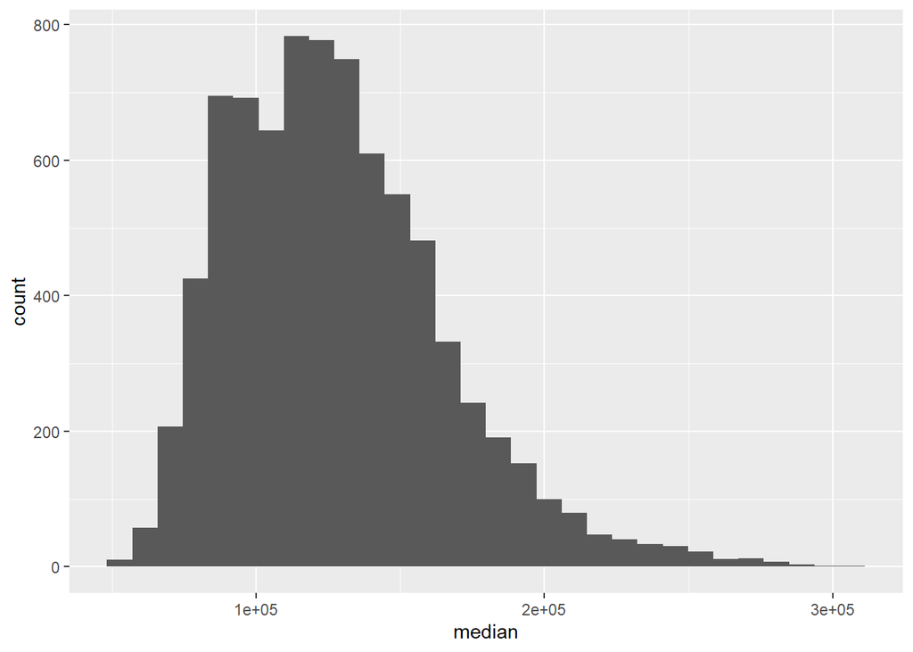

```r
ggplot(txhousing,aes(median)) +
  geom_histogram()
```

- There is a bit of missingness here. We can handle it a variety of ways. I take an easy route of excluding the data, but you should think more carefully about this in your actual projects.

```r
## Preprocessing - Missing data
## exclude all missing
## notice I made an assignment for both R and h2o here!
## this does not assign in place
txhousing_nomiss.hex <-
  h2o.assign(h2o.na_omit(txhousing.hex),
             'txhousing_nomiss.hex')
h2o.ls()
```

```
##                    key
## 1        txhousing.hex
## 2 txhousing_nomiss.hex
```

```r
## could also impute missing
## this does assign in place!
## create new copy
txhousing_impute.hex <-
  h2o.assign(txhousing.hex,
             'txhousing_impute.hex')
## count missing by column
cbind(h2o.colnames(txhousing_impute.hex),
      h2o.nacnt(txhousing_impute.hex))
```

```
##       [,1]        [,2]
##  [1,] "city"      "0"
##  [2,] "year"      "0"
##  [3,] "month"     "0"
##  [4,] "sales"     "568"
##  [5,] "volume"    "568"
##  [6,] "median"    "616"
##  [7,] "listings"  "1424"
##  [8,] "inventory" "1467"
##  [9,] "date"      "0"
```

```r
## make imputations (updates the h2o.dataframe in place)
## default is mean here
h2o.impute(txhousing_impute.hex)
```

```
## [1] 0.000000e+00 2.007299e+03 6.406417e+00 5.495646e+02 1.068586e+08 1.281314e+05 3.216902e+03 7.174590e+00 2.007750e+03
```

```r
## count missing by column
cbind(h2o.colnames(txhousing_impute.hex),
      h2o.nacnt(txhousing_impute.hex))
```

```
##       [,1]        [,2]
##  [1,] "city"      "0"
##  [2,] "year"      "0"
##  [3,] "month"     "0"
##  [4,] "sales"     "0"
##  [5,] "volume"    "0"
##  [6,] "median"    "0"
##  [7,] "listings"  "0"
##  [8,] "inventory" "0"
##  [9,] "date"      "0"
```

```r
## No missing left!
## You should probably think carefully about
## your data imputation schemes!
```

# Make Training/Validation/Testing Splits

- I will use internal cross validation on the training data, so I am only making one split here.
- You can use the `h2o.splitFrame()` function to do simple splits based on proportions.
- It will not be exact, but rather just approximate. Remember, this is for typically large dataset, so and approximately exact split is fine.

```r
## Make a training, and testing split
txhousing_impute_split <-
  h2o.splitFrame(txhousing_impute.hex)
## Identify training
txhousing_train <-
  txhousing_impute_split[[1]]
## Identify testing
txhousing_test <-
  txhousing_impute_split[[2]]
## Notice the key store is not getting updated
h2o.ls()
```

```
##                    key
## 1        txhousing.hex
## 2 txhousing_impute.hex
## 3 txhousing_nomiss.hex
```

```r
## That is fine. The R Pointer still works
## The object just has a different name in the h2o store
```

# Standard Regression in H2O

- We will start by implementing what I think of as ‘standard’ regression using h2o.
- This is a general linear model, with an identity link and a Gaussian family. This is called normal linear regression, or just linear regression.
- If we are talking about machine learning, why am I showing you basic linear regression?!?
- This is actually really useful. H2O has implemented a distributed version of traditional linear regression, including likelihood based statistics and p-values available.
- If you are interested in inference (instead of just prediction), you should be doing this sort of thing instead of the ‘fancier’ machine learning models.
- If you are working on big enough data, you can run out of memory even doing basic linear models like this. So this is a great addition to R from H2O.
- The `h2o.glm()` function also allows regularization (for things like elastic net, LASSO, or ridge regression). For now we will focus on regular GLM with no regularization.
- I usually start by fitting a ‘null model’ (an intercept only model). I am not sure how to do that in H2O though (maybe not currently possible - I get errors about needing at least one variable), so I begin with a predictor already in the model.
- Let’s start by fitting the model:

```r
## GLM - Gaussian
## Standard model (no regularization)
## The default is to standardize the predictors prior to fitting
## this is reasonable to do!
## Compute p-values is allowed since there is no regularization.
tx_glm_1 <-
  h2o.glm(y = 'median',
          x = 'sales',
          training_frame = txhousing_train,
          model_id = 'tx_glm_1',
          family = 'gaussian',
          lambda=0,
          compute_p_values = T)
```

- The returning object is an H2O model object, which is in the H2O workspace (not the R workspace). The object we see in R is just a pointer!
- You can summarize the model using the following commands:

```r
## Checkout model
summary(tx_glm_1)
```

```
## Model Details:
## ==============
##
## H2ORegressionModel: glm
## Model Key:  tx_glm_1
## GLM Model: summary
##     family     link regularization number_of_predictors_total number_of_active_predictors number_of_iterations   training_frame
## 1 gaussian identity           None                          1                           1                    1 RTMP_sid_b563_78
##
## H2ORegressionMetrics: glm
## ** Reported on training data. **
##
## MSE:  1137081189
## RMSE:  33720.63
## MAE:  25447.98
## RMSLE:  0.2584994
## Mean Residual Deviance :  1137081189
## R^2 :  0.1196995
## Null Deviance :8.256525e+12
## Null D.o.F. :6391
## Residual Deviance :7.268223e+12
## Residual D.o.F. :6390
## AIC :151430
##
##
##
##
##
## Scoring History:
##             timestamp   duration iterations negative_log_likelihood        objective training_rmse training_deviance training_mae training_r2
## 1 2020-08-23 16:41:33  0.000 sec          0     8256524549232.12012 1291696581.54445            NA                NA           NA          NA
##
## Variable Importances: (Extract with `h2o.varimp`)
## =================================================
##
##   variable relative_importance scaled_importance percentage
## 1    sales            12435.42                 1          1
```

```r
tx_glm_1
```

```
## Model Details:
## ==============
##
## H2ORegressionModel: glm
## Model ID:  tx_glm_1
## GLM Model: summary
##     family     link regularization number_of_predictors_total number_of_active_predictors number_of_iterations   training_frame
## 1 gaussian identity           None                          1                           1                    1 RTMP_sid_b563_78
##
## Coefficients: glm coefficients
##       names  coefficients  std_error    z_value  p_value standardized_coefficients
## 1 Intercept 121791.862397 473.167138 257.397128 0.000000             128109.828918
## 2     sales     11.486825   0.389690  29.476849 0.000000              12435.416569
##
## H2ORegressionMetrics: glm
## ** Reported on training data. **
##
## MSE:  1137081189
## RMSE:  33720.63
## MAE:  25447.98
## RMSLE:  0.2584994
## Mean Residual Deviance :  1137081189
## R^2 :  0.1196995
## Null Deviance :8.256525e+12
## Null D.o.F. :6391
## Residual Deviance :7.268223e+12
## Residual D.o.F. :6390
## AIC :151430
```

```r
h2o.aic(tx_glm_1) # AIC is penalized likelihood
```

```
## [1] 151430
```

```r
h2o.mse(tx_glm_1)
```

```
## [1] 1137081189
```

```r
## Overall performance
h2o.performance(tx_glm_1)
```

```
## H2ORegressionMetrics: glm
## ** Reported on training data. **
##
## MSE:  1137081189
## RMSE:  33720.63
## MAE:  25447.98
## RMSLE:  0.2584994
## Mean Residual Deviance :  1137081189
## R^2 :  0.1196995
## Null Deviance :8.256525e+12
## Null D.o.F. :6391
## Residual Deviance :7.268223e+12
## Residual D.o.F. :6390
## AIC :151430
```

# Model Evaluation

- There is functionality for calculating variable importance.
- This uses the standardized model coefficients
- However, I did not standardize the outcome…so the range is still large.
- The plot function doesn’t work well as a result, but I will show you a version using GGPlot2 on the next model.

```r
## Variable importance
h2o.varimp(tx_glm_1)
```

```
##   variable relative_importance scaled_importance percentage
## 1    sales            12435.42                 1          1
```

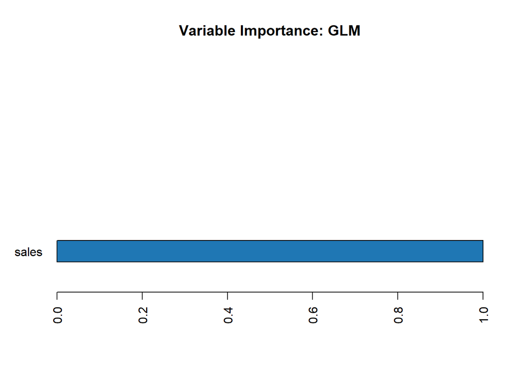

```r
## Plot function is off a bit in range
h2o.varimp_plot(tx_glm_1)
```

- The model coefficients can be extracted easily, and you can make predictions on new datasets.

```r
## Extract Coefficients
tx_glm_1@model$coefficients_table
```

```
## Coefficients: glm coefficients
##       names  coefficients  std_error    z_value  p_value standardized_coefficients
## 1 Intercept 121791.862397 473.167138 257.397128 0.000000             128109.828918
## 2     sales     11.486825   0.389690  29.476849 0.000000              12435.416569
```

```r
## Make predictions on new data
h2o.predict(tx_glm_1,
            newdata = txhousing_test)
```

```
##    predict   StdErr
## 1 123285.1 452.4788
## 2 123583.8 448.9132
## 3 122952.0 456.6883
## 4 123526.4 449.5833
## 5 123021.0 455.7976
## 6 123342.6 451.7777
##
## [2210 rows x 2 columns]
```

- You can also score a new dataset and request performance metrics with one call:

```r
h2o.performance(tx_glm_1,
                newdata = txhousing_test)
```

```
## H2ORegressionMetrics: glm
##
## MSE:  1154770332
## RMSE:  33981.91
## MAE:  25505.56
## RMSLE:  0.2603743
## Mean Residual Deviance :  1154770332
## R^2 :  0.1164606
## Null Deviance :2.888446e+12
## Null D.o.F. :2209
## Residual Deviance :2.552042e+12
## Residual D.o.F. :2208
## AIC :52394.15
```

# Regression with Multiple Predictors

- There is no formula style interface for these modeling objects. So if you want multiple predictors, you will need to pass in a vector of strings of the predictors in the model.

```r
## Implement Multiple Predictors
## GLM - Gaussian
## Standard model (no regularization)
## Compute p-values
x_pred <-
  c('year','month','sales','volume',
    'listings','inventory')
tx_glm_2 <-
  h2o.glm(y = 'median',
          x = x_pred,
          training_frame = txhousing_train,
          model_id = 'tx_glm_2',
          family = 'gaussian',
          lambda=0,
          compute_p_values = T)
## Checkout model
tx_glm_2
```

```
## Model Details:
## ==============
##
## H2ORegressionModel: glm
## Model ID:  tx_glm_2
## GLM Model: summary
##     family     link regularization number_of_predictors_total number_of_active_predictors number_of_iterations   training_frame
## 1 gaussian identity           None                          6                           6                    1 RTMP_sid_b563_78
##
## Coefficients: glm coefficients
##       names    coefficients     std_error    z_value  p_value standardized_coefficients
## 1 Intercept -6531249.737110 165025.244219 -39.577277 0.000000             128109.828918
## 2      year     3317.655684     82.218293  40.351795 0.000000              14906.279286
## 3     month      507.527351    101.213964   5.014400 0.000001               1752.233010
## 4     sales      -27.614053      2.547343 -10.840336 0.000000             -29894.444269
## 5    volume        0.000172      0.000009  18.815458 0.000000              41225.378741
## 6  listings        0.152470      0.184656   0.825695 0.409008                829.349656
## 7 inventory     -998.085539     88.817153 -11.237531 0.000000              -4099.628992
##
## H2ORegressionMetrics: glm
## ** Reported on training data. **
##
## MSE:  776053692
## RMSE:  27857.74
## MAE:  21916.34
## RMSLE:  0.2143965
## Mean Residual Deviance :  776053692
## R^2 :  0.3991982
## Null Deviance :8.256525e+12
## Null D.o.F. :6391
## Residual Deviance :4.960535e+12
## Residual D.o.F. :6385
## AIC :148998.2
```

```r
summary(tx_glm_2)
```

```
## Model Details:
## ==============
##
## H2ORegressionModel: glm
## Model Key:  tx_glm_2
## GLM Model: summary
##     family     link regularization number_of_predictors_total number_of_active_predictors number_of_iterations   training_frame
## 1 gaussian identity           None                          6                           6                    1 RTMP_sid_b563_78
##
## H2ORegressionMetrics: glm
## ** Reported on training data. **
##
## MSE:  776053692
## RMSE:  27857.74
## MAE:  21916.34
## RMSLE:  0.2143965
## Mean Residual Deviance :  776053692
## R^2 :  0.3991982
## Null Deviance :8.256525e+12
## Null D.o.F. :6391
## Residual Deviance :4.960535e+12
## Residual D.o.F. :6385
## AIC :148998.2
##
##
##
##
##
## Scoring History:
##             timestamp   duration iterations negative_log_likelihood        objective training_rmse training_deviance training_mae training_r2
## 1 2020-08-23 16:41:33  0.000 sec          0     8256524549232.12012 1291696581.54445            NA                NA           NA          NA
##
## Variable Importances: (Extract with `h2o.varimp`)
## =================================================
##
##    variable relative_importance scaled_importance  percentage
## 1    volume          41225.3787        1.00000000 0.444683132
## 2     sales          29894.4443        0.72514663 0.322460473
## 3      year          14906.2793        0.36158017 0.160788601
## 4 inventory           4099.6290        0.09944430 0.044221203
## 5     month           1752.2330        0.04250375 0.018900699
## 6  listings            829.3497        0.02011745 0.008945892
```

```r
h2o.aic(tx_glm_2)
```

```
## [1] 148998.2
```

```r
h2o.mse(tx_glm_2)
```

```
## [1] 776053692
```

- And we can evaluate the performance just as we did before.

```r
## Overall performance
h2o.performance(tx_glm_2)
```

```
## H2ORegressionMetrics: glm
## ** Reported on training data. **
##
## MSE:  776053692
## RMSE:  27857.74
## MAE:  21916.34
## RMSLE:  0.2143965
## Mean Residual Deviance :  776053692
## R^2 :  0.3991982
## Null Deviance :8.256525e+12
## Null D.o.F. :6391
## Residual Deviance :4.960535e+12
## Residual D.o.F. :6385
## AIC :148998.2
```

- I mentioned the plotting functionality for variable importance was strange.
- Here is some sample code leveraging GGPlot2 to get a better plot:

```r
## Variable importance
h2o.varimp(tx_glm_2)
```

```
##    variable relative_importance scaled_importance  percentage
## 1    volume          41225.3787        1.00000000 0.444683132
## 2     sales          29894.4443        0.72514663 0.322460473
## 3      year          14906.2793        0.36158017 0.160788601
## 4 inventory           4099.6290        0.09944430 0.044221203
## 5     month           1752.2330        0.04250375 0.018900699
## 6  listings            829.3497        0.02011745 0.008945892
```

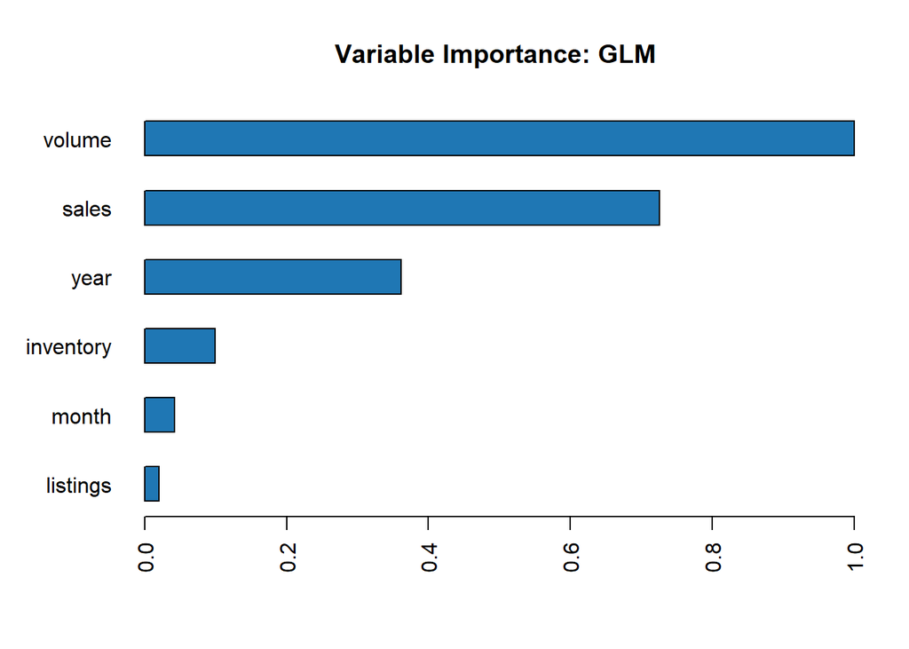

```r
## Plot function is off a bit in range (if using older version of h2o)
## I think because the outcome is not standardized (only predictors).
h2o.varimp_plot(tx_glm_2)
```

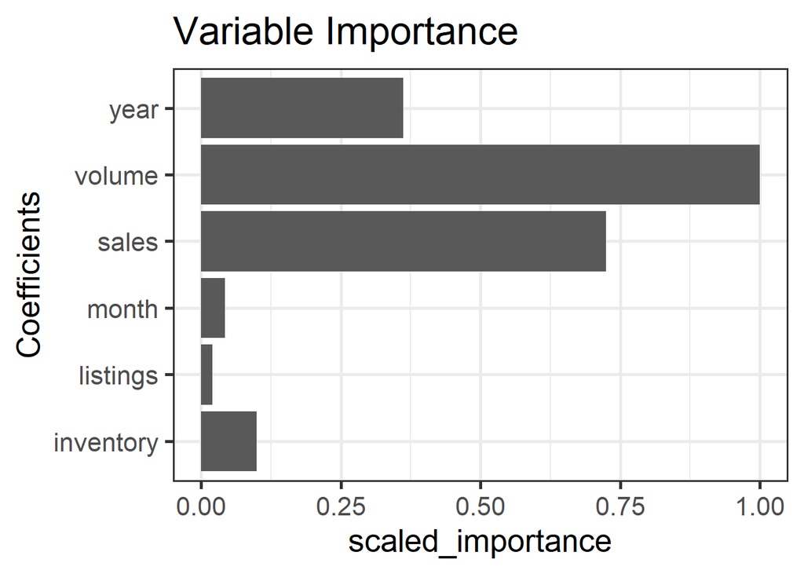

```r
## Make our own with ggplot
x1 <- as.data.table(h2o.varimp(tx_glm_2))
ggplot(x1[!is.na(variable)],
       aes(variable,scaled_importance)) +
  geom_col() +
  coord_flip() +
  labs(x='Coefficients',
       title='Variable Importance') +
  theme_bw(20)
```

- Extract the coefficients, or score new data:

```r
## Extract Model Coefficients
tx_glm_2@model$coefficients_table
```

```
## Coefficients: glm coefficients
##       names    coefficients     std_error    z_value  p_value standardized_coefficients
## 1 Intercept -6531249.737110 165025.244219 -39.577277 0.000000             128109.828918
## 2      year     3317.655684     82.218293  40.351795 0.000000              14906.279286
## 3     month      507.527351    101.213964   5.014400 0.000001               1752.233010
## 4     sales      -27.614053      2.547343 -10.840336 0.000000             -29894.444269
## 5    volume        0.000172      0.000009  18.815458 0.000000              41225.378741
## 6  listings        0.152470      0.184656   0.825695 0.409008                829.349656
## 7 inventory     -998.085539     88.817153 -11.237531 0.000000              -4099.628992
```

```r
## Make predictions on new data
h2o.predict(tx_glm_2,
            newdata = txhousing_test)
```

```
##     predict   StdErr
## 1  96922.37 791.3377
## 2  98720.70 703.0959
## 3 101086.68 777.9233
## 4 101754.82 652.1918
## 5 104336.06 677.6366
## 6 104626.34 629.8100
##
## [2210 rows x 2 columns]
```

# Nonlinear terms, or functions of terms

- Since we have no formula style interface here, we must actually create any nonlinear terms in the model.
- We can then add them as predictors. As an example, consider a polynomial regression with sales:

```r
#### non-linear terms
## No formula interface
## must make these manually
txhousing_train$sales_squared <-
  txhousing_train$sales**2
txhousing_test$sales_squared <-
  txhousing_test$sales**2
## Add predictors
x_pred <-
  c('year','month','sales','sales_squared',
    'volume','listings','inventory')

tx_glm_3 <-
  h2o.glm(y = 'median',
          x = x_pred,
          training_frame = txhousing_train,
          model_id = 'tx_glm_3',
          family = 'gaussian',
          lambda=0,
          compute_p_values = T)
## Checkout model
summary(tx_glm_3)
```

```
## Model Details:
## ==============
##
## H2ORegressionModel: glm
## Model Key:  tx_glm_3
## GLM Model: summary
##     family     link regularization number_of_predictors_total number_of_active_predictors number_of_iterations   training_frame
## 1 gaussian identity           None                          7                           7                    1 RTMP_sid_b563_81
##
## H2ORegressionMetrics: glm
## ** Reported on training data. **
##
## MSE:  613055854
## RMSE:  24759.96
## MAE:  19204.97
## RMSLE:  0.1933117
## Mean Residual Deviance :  613055854
## R^2 :  0.5253871
## Null Deviance :8.256525e+12
## Null D.o.F. :6391
## Residual Deviance :3.918653e+12
## Residual D.o.F. :6384
## AIC :147493.2
##
##
##
##
##
## Scoring History:
##             timestamp   duration iterations negative_log_likelihood        objective training_rmse training_deviance training_mae training_r2
## 1 2020-08-23 16:41:34  0.000 sec          0     8256524549232.12012 1291696581.54445            NA                NA           NA          NA
##
## Variable Importances: (Extract with `h2o.varimp`)
## =================================================
##
##        variable relative_importance scaled_importance  percentage
## 1        volume           52564.256        1.00000000 0.469223463
## 2 sales_squared           38257.817        0.72782952 0.341514688
## 3          year           14552.176        0.27684546 0.129902385
## 4      listings            2755.857        0.05242835 0.024600610
## 5         month            1460.519        0.02778540 0.013037561
## 6         sales            1331.987        0.02534017 0.011890201
## 7     inventory            1101.318        0.02095183 0.009831093
```

```r
## COmpare fits
h2o.aic(tx_glm_2)
```

```
## [1] 148998.2
```

```r
h2o.aic(tx_glm_3)
```

```
## [1] 147493.2
```

```r
## lower AIC is better
## Overall performance
h2o.performance(tx_glm_3)
```

```
## H2ORegressionMetrics: glm
## ** Reported on training data. **
##
## MSE:  613055854
## RMSE:  24759.96
## MAE:  19204.97
## RMSLE:  0.1933117
## Mean Residual Deviance :  613055854
## R^2 :  0.5253871
## Null Deviance :8.256525e+12
## Null D.o.F. :6391
## Residual Deviance :3.918653e+12
## Residual D.o.F. :6384
## AIC :147493.2
```

```r
## Extract Model Coefficients
tx_glm_3@model$coefficients_table
```

```
## Coefficients: glm coefficients
##           names    coefficients     std_error    z_value  p_value standardized_coefficients
## 1     Intercept -6386323.554492 146728.128601 -43.524876 0.000000             128109.828918
## 2          year     3238.843681     73.106389  44.303155 0.000000              14552.175713
## 3         month      423.033476     89.989409   4.700925 0.000003               1460.518766
## 4         sales       -1.230381      2.353075  -0.522882 0.601074              -1331.987002
## 5        volume        0.000219      0.000008  26.724446 0.000000              52564.256332
## 6      listings       -0.506644      0.164913  -3.072185 0.002134              -2755.857059
## 7     inventory     -268.124066     80.910661  -3.313829 0.000925              -1101.317623
## 8 sales_squared       -0.006019      0.000146 -41.199063 0.000000             -38257.817424
```

# Interaction Terms in Models

- There will be some later modeling approaches that automatically handle potential interaction terms.
- However, we need to request them specifically when using a GLM framework (true for any glm, h2o or otherwise).
- With no formula style interface, interactions get a bit strange.
- You can identify a list of interaction variables, then h2o will perform all pairwise interactions.
- Alternatively, you can list the individual pairs of interactions you want to fit.

```r
#### Interactions
## These are hard!
## No formula
## we can add all pairwise interactions on a subset of predictors
## or list them out specifically
## Add predictors
x_pred <-
  c('year','month','sales','sales_squared',
    'volume','listings','inventory')
tx_glm_4 <-
  h2o.glm(y = 'median',
          x = x_pred,
          training_frame = txhousing_train,
          model_id = 'tx_glm_4',
          family = 'gaussian',
          interaction_pairs = list(c('inventory','year'),
                                   c('volume','year')),
          lambda=0,
          compute_p_values = T)
## Checkout model
summary(tx_glm_4)
```

```
## Model Details:
## ==============
##
## H2ORegressionModel: glm
## Model Key:  tx_glm_4
## GLM Model: summary
##     family     link regularization number_of_predictors_total number_of_active_predictors number_of_iterations   training_frame
## 1 gaussian identity           None                          9                           9                    1 RTMP_sid_b563_81
##
## H2ORegressionMetrics: glm
## ** Reported on training data. **
##
## MSE:  534547235
## RMSE:  23120.28
## MAE:  17311.87
## RMSLE:  0.1790492
## Mean Residual Deviance :  534547235
## R^2 :  0.5861666
## Null Deviance :8.256525e+12
## Null D.o.F. :6391
## Residual Deviance :3.416826e+12
## Residual D.o.F. :6382
## AIC :146621.3
##
##
##
##
##
## Scoring History:
##             timestamp   duration iterations negative_log_likelihood        objective training_rmse training_deviance training_mae training_r2
## 1 2020-08-23 16:41:35  0.000 sec          0     8256524549232.12012 1291696581.54445            NA                NA           NA          NA
##
## Variable Importances: (Extract with `h2o.varimp`)
## =================================================
##
##         variable relative_importance scaled_importance   percentage
## 1         volume         7379408.798      1.0000000000 4.700739e-01
## 2    volume_year         7261353.663      0.9840020876 4.625537e-01
## 3 inventory_year          464785.117      0.0629840587 2.960716e-02
## 4      inventory          462761.288      0.0627098051 2.947824e-02
## 5          sales           69854.707      0.0094661658 4.449797e-03
## 6  sales_squared           36295.329      0.0049184603 2.312040e-03
## 7           year           19335.630      0.0026202139 1.231694e-03
## 8       listings            3424.660      0.0004640833 2.181534e-04
## 9          month            1183.518      0.0001603811 7.539095e-05
```

```r
## Compare fits
h2o.aic(tx_glm_3)
```

```
## [1] 147493.2
```

```r
h2o.aic(tx_glm_4)
```

```
## [1] 146621.3
```

```r
## lower AIC is better
## Overall performance
h2o.performance(tx_glm_4)
```

```
## H2ORegressionMetrics: glm
## ** Reported on training data. **
##
## MSE:  534547235
## RMSE:  23120.28
## MAE:  17311.87
## RMSLE:  0.1790492
## Mean Residual Deviance :  534547235
## R^2 :  0.5861666
## Null Deviance :8.256525e+12
## Null D.o.F. :6391
## Residual Deviance :3.416826e+12
## Residual D.o.F. :6382
## AIC :146621.3
```

```r
## All pairwise interactions
## Add predictors
x_pred <-
  c('year','month','sales','sales_squared',
    'volume','listings','inventory')
tx_glm_5 <-
  h2o.glm(y = 'median',
          x = x_pred,
          training_frame = txhousing_train,
          model_id = 'tx_glm_5',
          family = 'gaussian',
          interactions = c('year','sales','volume'),
          lambda=0,
          compute_p_values = T)
## Checkout model
summary(tx_glm_5)
```

```
## Model Details:
## ==============
##
## H2ORegressionModel: glm
## Model Key:  tx_glm_5
## GLM Model: summary
##     family     link regularization number_of_predictors_total number_of_active_predictors number_of_iterations   training_frame
## 1 gaussian identity           None                         10                          10                    1 RTMP_sid_b563_81
##
## H2ORegressionMetrics: glm
## ** Reported on training data. **
##
## MSE:  522866195
## RMSE:  22866.27
## MAE:  17250.1
## RMSLE:  0.1782047
## Mean Residual Deviance :  522866195
## R^2 :  0.5952097
## Null Deviance :8.256525e+12
## Null D.o.F. :6391
## Residual Deviance :3.342161e+12
## Residual D.o.F. :6381
## AIC :146482.1
##
##
##
##
##
## Scoring History:
##             timestamp   duration iterations negative_log_likelihood        objective training_rmse training_deviance training_mae training_r2
## 1 2020-08-23 16:41:35  0.000 sec          0     8256524549232.12012 1291696581.54445            NA                NA           NA          NA
##
## Variable Importances: (Extract with `h2o.varimp`)
## =================================================
##
##         variable relative_importance scaled_importance   percentage
## 1         volume         2990063.630      1.0000000000 0.2664307913
## 2    year_volume         2842337.406      0.9505942876 0.2532675882
## 3     year_sales         2695888.492      0.9016157601 0.2402182004
## 4          sales         2597444.777      0.8686921413 0.2314463346
## 5   sales_volume           55063.832      0.0184156056 0.0049064844
## 6  sales_squared           18721.407      0.0062612069 0.0016681783
## 7           year           16402.442      0.0054856497 0.0014615460
## 8       listings            3739.811      0.0012507463 0.0003332373
## 9      inventory            1778.865      0.0005949256 0.0001585065
## 10         month            1224.764      0.0004096112 0.0001091330
```

```r
## Compare fits
h2o.aic(tx_glm_3)
```

```
## [1] 147493.2
```

```r
h2o.aic(tx_glm_4)
```

```
## [1] 146621.3
```

```r
h2o.aic(tx_glm_5)
```

```
## [1] 146482.1
```

# Categorical Predictors

- Categorical predictors must be factors in h2o, they cannot be characters.
- Otherwise, they work as you would expect.
- Dummy coding happens automatically.
- The H2O manual specifically states to let GLM do the dummy coding - do no try to create them ahead of time. This is highly inefficient.

```r
## add a categorical predictor
## do not encode ahead of time! Let GLM do it
## make a factor
txhousing_train$city_f <-
  as.factor(txhousing_train$city)
## Add predictors
x_pred <-
  c('year','month','sales','sales_squared',
    'volume','listings','inventory','city_f')
tx_glm_6 <-
  h2o.glm(y = 'median',
          x = x_pred,
          training_frame = txhousing_train,
          model_id = 'tx_glm_6',
          family = 'gaussian',
          lambda=0,
          compute_p_values = T)
## Checkout model
summary(tx_glm_6)
```

```
## Model Details:
## ==============
##
## H2ORegressionModel: glm
## Model Key:  tx_glm_6
## GLM Model: summary
##     family     link regularization number_of_predictors_total number_of_active_predictors number_of_iterations   training_frame
## 1 gaussian identity           None                         52                          52                    1 RTMP_sid_b563_82
##
## H2ORegressionMetrics: glm
## ** Reported on training data. **
##
## MSE:  206355277
## RMSE:  14365.07
## MAE:  10277.63
## RMSLE:  0.1155316
## Mean Residual Deviance :  206355277
## R^2 :  0.8402448
## Null Deviance :8.256525e+12
## Null D.o.F. :6391
## Residual Deviance :1.319023e+12
## Residual D.o.F. :6339
## AIC :140623.3
##
##
##
##
##
## Scoring History:
##             timestamp   duration iterations negative_log_likelihood        objective training_rmse training_deviance training_mae training_r2
## 1 2020-08-23 16:41:35  0.000 sec          0     8256524549232.12012 1291696581.54445            NA                NA           NA          NA
##
## Variable Importances: (Extract with `h2o.varimp`)
## =================================================
##
##                        variable relative_importance scaled_importance   percentage
## 1          city_f.Collin County          76875.7069       1.000000000 0.0649969005
## 2              city_f.Fort Bend          67415.0644       0.876935864 0.0569981131
## 3                city_f.Midland          61426.7461       0.799039756 0.0519351075
## 4      city_f.Montgomery County          60572.9745       0.787933886 0.0512132604
```

[output cut: 33 more lines]

```
## 38                city_f.Lufkin           7958.9977       0.103530725 0.0067291762
## 39             city_f.Harlingen           6894.3319       0.089681542 0.0058290222
## 40               city_f.Lubbock           6529.5834       0.084936890 0.0055206346
## 41         city_f.Wichita Falls           5840.0245       0.075967100 0.0049376261
## 42               city_f.Houston           5769.9109       0.075055061 0.0048783463
## 43       city_f.Sherman-Denison           4272.8430       0.055581187 0.0036126049
## 44            city_f.Fort Worth           3833.9551       0.049872128 0.0032415337
## 45               city_f.McAllen           3248.4702       0.042256134 0.0027465177
## 46             city_f.Texarkana           2556.1617       0.033250578 0.0021611845
## 47                        month           1874.8371       0.024387901 0.0015851380
## 48           city_f.Brownsville           1836.8123       0.023893274 0.0015529887
## 49                city_f.Dallas           1336.9343       0.017390856 0.0011303517
## 50                     listings            847.5612       0.011025085 0.0007165964
## 51                    inventory            286.8127       0.003730863 0.0002424945
## 52           city_f.Port Arthur            252.0146       0.003278208 0.0002130734
```

```r
## Compare fits
h2o.aic(tx_glm_3)
```

```
## [1] 147493.2
```

```r
h2o.aic(tx_glm_4)
```

```
## [1] 146621.3
```

```r
h2o.aic(tx_glm_5)
```

```
## [1] 146482.1
```

```r
h2o.aic(tx_glm_6)
```

```
## [1] 140623.3
```

# Extending the GLM

- A general linear model is defined by a link function and a family.
- We typically extend the general linear model by either changing the link function, or changing the underlying family.
- H2O allows “gaussian”, “binomial”, “quasibinomial”, “ordinal”, “multinomial”, “poisson”, “gamma”, or “tweedie” families
- H2O allows the following link functions: “identity”, “logit”, “log”, “inverse”, “tweedie”, “ologit”, “oprobit”, “ologlog”
- I typically only use identity, log, and logit link functions.

```r
## Try a lognormal regression
x_pred <-
  c('year','month','sales','sales_squared',
    'volume','listings','inventory')
tx_glm_7 <-
  h2o.glm(y = 'median',
          x = x_pred,
          training_frame = txhousing_train,
          model_id = 'tx_glm_7',
          family = 'gaussian',
          link = 'log',
          lambda=0,
          compute_p_values = T)
## Checkout model
summary(tx_glm_7)
```

```
## Model Details:
## ==============
##
## H2ORegressionModel: glm
## Model Key:  tx_glm_7
## GLM Model: summary
##     family link regularization number_of_predictors_total number_of_active_predictors number_of_iterations   training_frame
## 1 gaussian  log           None                          7                           7                    6 RTMP_sid_b563_82
##
## H2ORegressionMetrics: glm
## ** Reported on training data. **
##
## MSE:  659692849
## RMSE:  25684.49
## MAE:  20233.58
## RMSLE:  0.2009596
## Mean Residual Deviance :  659692849
## R^2 :  0.4892819
## Null Deviance :8.256525e+12
## Null D.o.F. :6391
## Residual Deviance :4.216757e+12
## Residual D.o.F. :6384
## AIC :147961.9
##
##
##
##
##
## Scoring History:
##             timestamp   duration iterations negative_log_likelihood       objective training_rmse training_deviance training_mae training_r2
## 1 2020-08-23 16:41:36  0.000 sec          0     4128262274616.06006 645848290.77223            NA                NA           NA          NA
## 2 2020-08-23 16:41:36  0.002 sec          1     2683779203933.08984 419865332.27990            NA                NA           NA          NA
## 3 2020-08-23 16:41:36  0.002 sec          2     2114009533012.69995 330727398.78171            NA                NA           NA          NA
## 4 2020-08-23 16:41:36  0.003 sec          3     2108442480912.12012 329856458.21529            NA                NA           NA          NA
## 5 2020-08-23 16:41:36  0.004 sec          4     2108380697321.37012 329846792.44702            NA                NA           NA          NA
## 6 2020-08-23 16:41:36  0.004 sec          5     2108378424295.33008 329846436.84220            NA                NA           NA          NA
## 7 2020-08-23 16:41:36  0.005 sec          6     2108378330645.66992 329846422.19112   25684.48654   659692848.65624  20233.57854     0.48928
##
## Variable Importances: (Extract with `h2o.varimp`)
## =================================================
##
##        variable relative_importance scaled_importance  percentage
## 1        volume         0.257345591        1.00000000 0.375178705
## 2 sales_squared         0.244163326        0.94877602 0.355960559
## 3          year         0.114831377        0.44621466 0.167410240
## 4         sales         0.035058548        0.13623139 0.051111117
## 5     inventory         0.017697618        0.06876985 0.025800984
## 6         month         0.012873986        0.05002606 0.018768713
## 7      listings         0.003957587        0.01537849 0.005769683
```

```r
## Compare fits
h2o.aic(tx_glm_3)
```

```
## [1] 147493.2
```

```r
h2o.aic(tx_glm_4)
```

```
## [1] 146621.3
```

```r
h2o.aic(tx_glm_5)
```

```
## [1] 146482.1
```

```r
h2o.aic(tx_glm_6)
```

```
## [1] 140623.3
```

```r
h2o.aic(tx_glm_7) # not better!
```

```
## [1] 147961.9
```

# Regularized General Linear Models (Elastic Net)

# Elastic Net: Ridge Regression

- We will start with a Ridge Regression (alpha==0)
- You can specify the penalty (lambda) to be a specific number, or you can request the penalty to be a range of numbers.
- We start with a specific penalty (lambda)

```r
#### regularized regression elastic net
## no p-values now
## specify lambda and alpha
## ridge is alpha == 0
## lasso is alpha == 1
## elastic net is alpha in between
## Single lambda for now
## use test data for validation metrics!
x_pred <-
  c('year','month','sales','sales_squared',
    'volume','listings','inventory','city_f')
tx_enet_1 <-
  h2o.glm(y = 'median',
          x = x_pred,
          training_frame = txhousing_train,
          validation_frame = txhousing_test,
          model_id = 'tx_enet_1',
          family = 'gaussian',
          alpha=0,
          lambda = 2)
## Checkout model
summary(tx_enet_1)
```

```
## Model Details:
## ==============
##
## H2ORegressionModel: glm
## Model Key:  tx_enet_1
## GLM Model: summary
##     family     link         regularization number_of_predictors_total number_of_active_predictors number_of_iterations   training_frame
## 1 gaussian identity Ridge ( lambda = 2.0 )                         53                          53                    1 RTMP_sid_b563_82
##
## H2ORegressionMetrics: glm
## ** Reported on training data. **
##
## MSE:  976130321
## RMSE:  31243.08
## MAE:  23868
## RMSLE:  0.2411559
## Mean Residual Deviance :  976130321
## R^2 :  0.2443037
## Null Deviance :8.256525e+12
## Null D.o.F. :6391
## Residual Deviance :6.239425e+12
## Residual D.o.F. :6338
## AIC :150558.4
##
##
## H2ORegressionMetrics: glm
## ** Reported on validation data. **
##
## MSE:  1003041519
## RMSE:  31670.83
## MAE:  23967.09
## RMSLE:  0.2433462
## Mean Residual Deviance :  1003041519
## R^2 :  0.2325515
## Null Deviance :2.888446e+12
## Null D.o.F. :2209
## Residual Deviance :2.216722e+12
## Residual D.o.F. :2156
## AIC :52186.84
##
```

[output cut: 51 more lines]

```
## 39                city_f.Irving           127.25325       0.022550713 0.0050812643
## 40              city_f.Beaumont           110.40908       0.019565735 0.0044086708
## 41     city_f.Longview-Marshall           102.03684       0.018082081 0.0040743648
## 42                  city_f.Waco            93.81391       0.016624884 0.0037460203
## 43       city_f.Brazoria County            90.93850       0.016115329 0.0036312043
## 44           city_f.Nacogdoches            89.20813       0.015808689 0.0035621101
## 45                city_f.Dallas            83.21766       0.014747108 0.0033229084
## 46               city_f.El Paso            82.54103       0.014627202 0.0032958904
## 47              city_f.Victoria            73.79536       0.013077371 0.0029466731
## 48                city_f.Odessa            62.69280       0.011109872 0.0025033441
## 49           city_f.San Antonio            50.64015       0.008974006 0.0020220777
## 50                city_f.Laredo            16.74420       0.002967262 0.0006686015
## 51                 city_f.Tyler            14.27898       0.002530397 0.0005701644
## 52             city_f.Arlington            10.68285       0.001893123 0.0004265699
## 53        city_f.Corpus Christi            10.20312       0.001808107 0.0004074138
```

```r
tx_enet_1@model$lambda_best
```

```
## [1] 2
```

- It turns out that the fastest way to converge these sorts of models is to calculate a full ‘regularization path’, which means calculating the same model for a range of lambdas.
- We typically would consider a range of lambdas from small to large, then use the validation data to pick a lambda.
- This is called optimizing a hyperparameter (lambda is a hyperparameter)
- Here is an example using the test data for validation (you would use the validation data here if you have it)

```r
## Now do a lambda search (regularization path)
## We can use the testing data to find optimal lambda
## use test data for validation metrics
x_pred <-
  c('year','month','sales','sales_squared',
    'volume','listings','inventory','city_f')
tx_enet_2 <-
  h2o.glm(y = 'median',
          x = x_pred,
          training_frame = txhousing_train,
          validation_frame = txhousing_test,
          model_id = 'tx_enet_2',
          family = 'gaussian',
          alpha=0,
          lambda_search = T)
## Checkout model
summary(tx_enet_2)
```

```
## Model Details:
## ==============
##
## H2ORegressionModel: glm
## Model Key:  tx_enet_2
## GLM Model: summary
##     family     link              regularization                                                                  lambda_search
## 1 gaussian identity Ridge ( lambda = 253890.0 ) nlambda = 30, lambda.max = 1707000.0, lambda.min = 253890.0, lambda.1se = -1.0
##   number_of_predictors_total number_of_active_predictors number_of_iterations   training_frame
## 1                         53                          53                    5 RTMP_sid_b563_82
##
## H2ORegressionMetrics: glm
## ** Reported on training data. **
##
## MSE:  1291689965
## RMSE:  35940.09
## MAE:  27306.67
## RMSLE:  0.2772055
## Mean Residual Deviance :  1291689965
## R^2 :  5.122441e-06
## Null Deviance :8.256525e+12
## Null D.o.F. :6391
## Residual Deviance :8.256482e+12
## Residual D.o.F. :6338
## AIC :152348.9
##
##
## H2ORegressionMetrics: glm
## ** Reported on validation data. **
##
## MSE:  1306982956
## RMSE:  36152.22
## MAE:  27102.98
## RMSLE:  0.2786609
## Mean Residual Deviance :  1306982956
## R^2 :  -5.64432e-07
## Null Deviance :2.888446e+12
## Null D.o.F. :2209
## Residual Deviance :2.888432e+12
## Residual D.o.F. :2156
```

[output cut: 61 more lines]

```
## 39              city_f.Beaumont        1.126825e-03      0.0167599302 3.183004e-03
## 40           city_f.San Antonio        1.059015e-03      0.0157513458 2.991457e-03
## 41     city_f.Longview-Marshall        1.012135e-03      0.0150540762 2.859033e-03
## 42           city_f.Nacogdoches        1.011463e-03      0.0150440771 2.857134e-03
## 43                  city_f.Waco        9.608847e-04      0.0142917973 2.714263e-03
## 44       city_f.Brazoria County        9.568458e-04      0.0142317240 2.702854e-03
## 45 city_f.Bryan-College Station        8.992209e-04      0.0133746351 2.540078e-03
## 46                city_f.Irving        8.139948e-04      0.0121070182 2.299335e-03
## 47              city_f.Victoria        7.974470e-04      0.0118608932 2.252592e-03
## 48               city_f.El Paso        7.033089e-04      0.0104607221 1.986674e-03
## 49                city_f.Odessa        3.577899e-04      0.0053216174 1.010668e-03
## 50                 city_f.Tyler        1.263946e-04      0.0018799404 3.570336e-04
## 51             city_f.Arlington        6.574056e-05      0.0009777976 1.857009e-04
## 52        city_f.Corpus Christi        3.001307e-05      0.0004464019 8.477955e-05
## 53                city_f.Laredo        2.103276e-05      0.0003128325 5.941238e-05
```

```r
tx_enet_2@model$lambda_best
```

```
## [1] 253887.5
```

```r
tx_enet_2@model$model_summary$lambda_search
```

```
## [1] "nlambda = 30, lambda.max = 1707000.0, lambda.min = 253890.0, lambda.1se = -1.0"
```

```r
## Compare fits
h2o.aic(tx_enet_1)
```

```
## [1] 150558.4
```

```r
h2o.aic(tx_enet_2)
```

```
## [1] 152348.9
```

- Instead, I prefer to cross validate internally with 10 fold cross validation.

```r
## Now do a lambda search (regularization path)
## Let's use internal cross validation instead of the test data
x_pred <-
  c('year','month','sales','sales_squared',
    'volume','listings','inventory','city_f')
tx_enet_3 <-
  h2o.glm(y = 'median',
          x = x_pred,
          training_frame = txhousing_train,
          nfolds = 10,
          model_id = 'tx_enet_3',
          family = 'gaussian',
          alpha=0,
          lambda_search = T,
          nlambdas = 100)
## Checkout model
summary(tx_enet_3)
```

```
## Model Details:
## ==============
##
## H2ORegressionModel: glm
## Model Key:  tx_enet_3
## GLM Model: summary
##     family     link               regularization                                                                         lambda_search
## 1 gaussian identity Ridge ( lambda = 1123100.0 ) nlambda = 100, lambda.max = 1707000.0, lambda.min = 1123100.0, lambda.1se = 1707000.0
##   number_of_predictors_total number_of_active_predictors number_of_iterations   training_frame
## 1                         53                          53                    5 RTMP_sid_b563_82
##
## H2ORegressionMetrics: glm
## ** Reported on training data. **
##
## MSE:  1291695086
## RMSE:  35940.16
## MAE:  27306.73
## RMSLE:  0.2772061
## Mean Residual Deviance :  1291695086
## R^2 :  1.158014e-06
## Null Deviance :8.256525e+12
## Null D.o.F. :6391
## Residual Deviance :8.256515e+12
## Residual D.o.F. :6338
## AIC :152348.9
##
##
##
## H2ORegressionMetrics: glm
## ** Reported on cross-validation data. **
## ** 10-fold cross-validation on training data (Metrics computed for combined holdout predictions) **
##
## MSE:  1292267598
## RMSE:  35948.12
## MAE:  27318.93
## RMSLE:  0.2772586
## Mean Residual Deviance :  1292267598
## R^2 :  -0.0004420667
## Null Deviance :8.260183e+12
## Null D.o.F. :6391
```

[output cut: 81 more lines]

```
## 39              city_f.Beaumont        2.547359e-04      0.0167599392 3.182996e-03
## 40           city_f.San Antonio        2.394079e-04      0.0157514550 2.991467e-03
## 41     city_f.Longview-Marshall        2.288084e-04      0.0150540809 2.859024e-03
## 42           city_f.Nacogdoches        2.286568e-04      0.0150441016 2.857129e-03
## 43                  city_f.Waco        2.172225e-04      0.0142918060 2.714255e-03
## 44       city_f.Brazoria County        2.163096e-04      0.0142317390 2.702848e-03
## 45 city_f.Bryan-College Station        2.032810e-04      0.0133745448 2.540052e-03
## 46                city_f.Irving        1.840143e-04      0.0121069262 2.299310e-03
## 47              city_f.Victoria        1.802752e-04      0.0118609156 2.252588e-03
## 48               city_f.El Paso        1.589933e-04      0.0104607049 1.986665e-03
## 49                city_f.Odessa        8.088295e-05      0.0053215631 1.010655e-03
## 50                 city_f.Tyler        2.857412e-05      0.0018799882 3.570415e-04
## 51             city_f.Arlington        1.486134e-05      0.0009777778 1.856965e-04
## 52        city_f.Corpus Christi        6.785372e-06      0.0004464326 8.478510e-05
## 53                city_f.Laredo        4.755413e-06      0.0003128747 5.942019e-05
```

```r
tx_enet_3@model$lambda_best
```

```
## [1] 1123076
```

```r
tx_enet_3@model$model_summary$lambda_search
```

```
## [1] "nlambda = 100, lambda.max = 1707000.0, lambda.min = 1123100.0, lambda.1se = 1707000.0"
```

```r
## the lambda min is not very small!
## the selected lambda was the min
## we have a range issue
```

- What do you think of the lambda, and the lambda range?
- There is an issue there! We have an oddly high ‘minimum’ lambda, and the minimum was selected as the best model.
- We should try for a better range of lambda, including lower numbers.
- You can specify the minimum lambda using the lambda argument, as long as you say lambda_search=T

```r
## let's make lambda min really small
## goal is to get a nice range of lambdas
tx_enet_4 <-
  h2o.glm(y = 'median',
          x = x_pred,
          training_frame = txhousing_train,
          nfolds = 10,
          model_id = 'tx_enet_4',
          family = 'gaussian',
          alpha=0,
          lambda = 0.001, # min
          nlambda=100, # total lambdas
          lambda_search = T)
summary(tx_enet_4)
```

```
## Model Details:
## ==============
##
## H2ORegressionModel: glm
## Model Key:  tx_enet_4
## GLM Model: summary
##     family     link           regularization                                                                 lambda_search
## 1 gaussian identity Ridge ( lambda = 0.001 ) nlambda = 100, lambda.max = 1707000.0, lambda.min = 0.001, lambda.1se = 0.001
##   number_of_predictors_total number_of_active_predictors number_of_iterations   training_frame
## 1                         53                          53                    1 RTMP_sid_b563_82
##
## H2ORegressionMetrics: glm
## ** Reported on training data. **
##
## MSE:  207531229
## RMSE:  14405.94
## MAE:  10257.99
## RMSLE:  0.1152469
## Mean Residual Deviance :  207531229
## R^2 :  0.8393344
## Null Deviance :8.256525e+12
## Null D.o.F. :6391
## Residual Deviance :1.32654e+12
## Residual D.o.F. :6338
## AIC :140661.6
##
##
##
## H2ORegressionMetrics: glm
## ** Reported on cross-validation data. **
## ** 10-fold cross-validation on training data (Metrics computed for combined holdout predictions) **
##
## MSE:  211474532
## RMSE:  14542.16
## MAE:  10341.36
## RMSLE:  0.1162713
## Mean Residual Deviance :  211474532
## R^2 :  0.8362816
## Null Deviance :8.258547e+12
## Null D.o.F. :6391
```

[output cut: 73 more lines]

```
## 39                        sales           7352.2892       0.143965247 0.0084240073
## 40         city_f.Temple-Belton           6745.4785       0.132083280 0.0077287438
## 41     city_f.Longview-Marshall           5836.2713       0.114280085 0.0066870046
## 42              city_f.Beaumont           5787.6312       0.113327663 0.0066312744
## 43                city_f.Laredo           4941.1689       0.096753076 0.0056614262
## 44                  city_f.Waco           4470.3783       0.087534520 0.0051220100
## 45                 city_f.Tyler           3254.1044       0.063718650 0.0037284441
## 46       city_f.Brazoria County           3072.8762       0.060170019 0.0035207988
## 47           city_f.Nacogdoches           2260.8065       0.044268875 0.0025903566
## 48        city_f.Corpus Christi           2136.8414       0.041841513 0.0024483215
## 49                        month           1859.9533       0.036419765 0.0021310724
## 50             city_f.Arlington           1853.1488       0.036286526 0.0021232760
## 51                     listings           1356.0749       0.026553315 0.0015537453
## 52              city_f.Victoria            839.0874       0.016430179 0.0009613983
## 53                    inventory            134.7883       0.002639291 0.0001544359
```

```r
tx_enet_4@model$lambda_best
```

```
## [1] 0.001
```

```r
tx_enet_4@model$model_summary$lambda_search
```

```
## [1] "nlambda = 100, lambda.max = 1707000.0, lambda.min = 0.001, lambda.1se = 0.001"
```